# ML Assignment2

Manasi Tondulkar | Student number : 20250123

Following libraries are used for data cleaning, pre-processing and for different classifiers.

```r
library(dplyr)
library(caTools)
library(nnet)
library(class)
library(pROC)
library(data.table)
library(readr)
library(ggplot2)
library(reshape2)
```

#### Importing and understanding data.

```r
data <- read.table("D:/Github/ml-assignment/train-io.txt", header = FALSE, sep = " ", dec = ".")
data <- data %>% rename(response = V13)
```

I have renamed the last column to ‘response’ as, the first 12 columns are inputs and the last one is output.  
For data cleaning, I have checked if there are any null values, as well as if the data is normalized.

```r
isNull <- sum(is.na(data))
isNull
```

```
## [1] 0
```

```r
summary(data)
```

```
##        V1                  V2                  V3
##  Min.   :-5.002253   Min.   :-9.426396   Min.   :-6.889677
##  1st Qu.:-0.952502   1st Qu.:-1.740190   1st Qu.:-1.298558
##  Median :-0.000281   Median : 0.008743   Median :-0.008429
##  Mean   : 0.001561   Mean   : 0.002457   Mean   :-0.005185
##  3rd Qu.: 0.955652   3rd Qu.: 1.740665   3rd Qu.: 1.286573
##  Max.   : 4.684574   Max.   : 8.898895   Max.   : 7.453131
##        V4                  V5                  V6
##  Min.   :-6.727678   Min.   :-6.814575   Min.   :-5.760816
##  1st Qu.:-1.241131   1st Qu.:-1.241468   1st Qu.:-0.993113
##  Median : 0.005833   Median : 0.000955   Median :-0.000509
##  Mean   : 0.006074   Mean   : 0.000741   Mean   :-0.000203
##  3rd Qu.: 1.250123   3rd Qu.: 1.239215   3rd Qu.: 0.986780
##  Max.   : 6.715654   Max.   : 6.548304   Max.   : 5.574340
##        V7                  V8                  V9
##  Min.   :-5.872210   Min.   :-6.586501   Min.   :-7.682507
##  1st Qu.:-1.123300   1st Qu.:-1.160992   1st Qu.:-1.348983
##  Median :-0.000990   Median : 0.002279   Median : 0.004482
##  Mean   :-0.002567   Mean   : 0.001268   Mean   : 0.001594
##  3rd Qu.: 1.120642   3rd Qu.: 1.162634   3rd Qu.: 1.354382
##  Max.   : 6.122361   Max.   : 6.354650   Max.   : 7.507812
##       V10                 V11                 V12               response
##  Min.   :-5.916694   Min.   :-9.062599   Min.   :-7.906362   Min.   :0.0000
##  1st Qu.:-1.250013   1st Qu.:-1.780738   1st Qu.:-1.617117   1st Qu.:0.0000
##  Median :-0.003854   Median : 0.002945   Median :-0.001004   Median :1.0000
##  Mean   :-0.000799   Mean   : 0.003028   Mean   : 0.000203   Mean   :0.5369
##  3rd Qu.: 1.250520   3rd Qu.: 1.789299   3rd Qu.: 1.622262   3rd Qu.:1.0000
##  Max.   : 6.293319   Max.   : 8.771217   Max.   : 7.918844   Max.   :1.0000
```

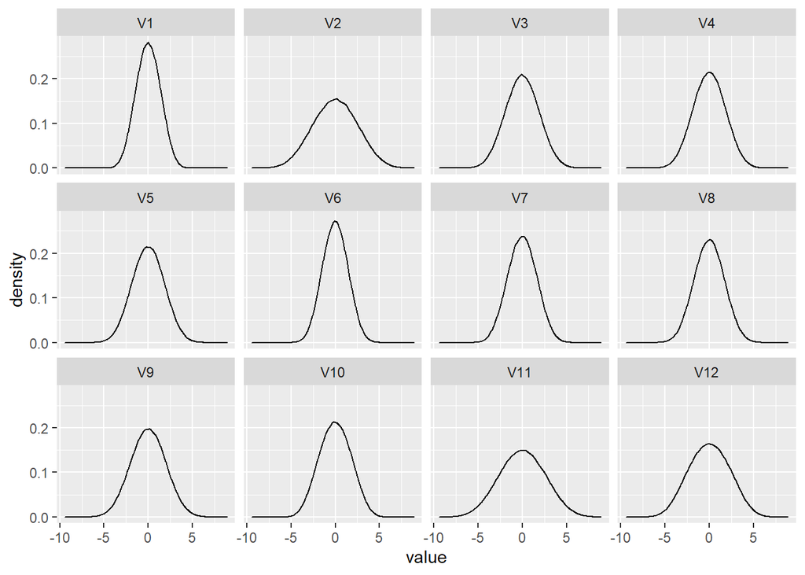

```r
ggplot(melt(subset(data,select=-c(response))), aes(x = value)) + geom_density()+facet_wrap(~variable)
```

##### Dividing data into training set and test data set.

```r
sampleSplit <- sample.split(Y=data$response, SplitRatio=0.70)
trainData <- subset(x=data, sampleSplit==TRUE)
testData <- subset(x=data, sampleSplit==FALSE)
```

#### Applying classification models

Models Used:  
1.Logistic Regression  
2.K nearest Neighbour  
3.Neural Network

##### 1.Logistic Regression

```r
fit_log<-glm(response~V1+V2+V3+V4+V5+V6+V7+V8+V9+V10+V11+V12, data = trainData,family = binomial)
res <- predict.glm(fit_log,testData)
res_log <- ifelse(res > 0.1450, 1, 0)
paste(mean(res_log == testData$response)*100,"%")
```

```
## [1] "50.75 %"
```

##### 2.KNN

```r
fit_knn <- knn(train = subset(trainData,select=-c(response)), test = subset(testData,select=-c(response)),cl = trainData$response, k=11)
paste(mean(fit_knn == testData$response)*100,"%")
```

```
## [1] "55.8211111111111 %"
```

##### 3.Neural Network

```r
fit_nn <- nnet.formula(formula = response~V1+V2+V3+V4+V5+V6+V7+V8+V9+V10+V11+V12, data = trainData, size = 175, linout = FALSE, rang = c(0.7), decay = 0.1, MaxNWts = 2700, maxit = 330)
res_nn <- predict(fit_nn,testData)
res_nn <- ifelse(res_nn < 0.5,0,1)
paste(mean(res_nn == testData$response)*100,"%")
```

```
## [1] "74.8266666666667 %"
```

#### Roc to compare all the models.

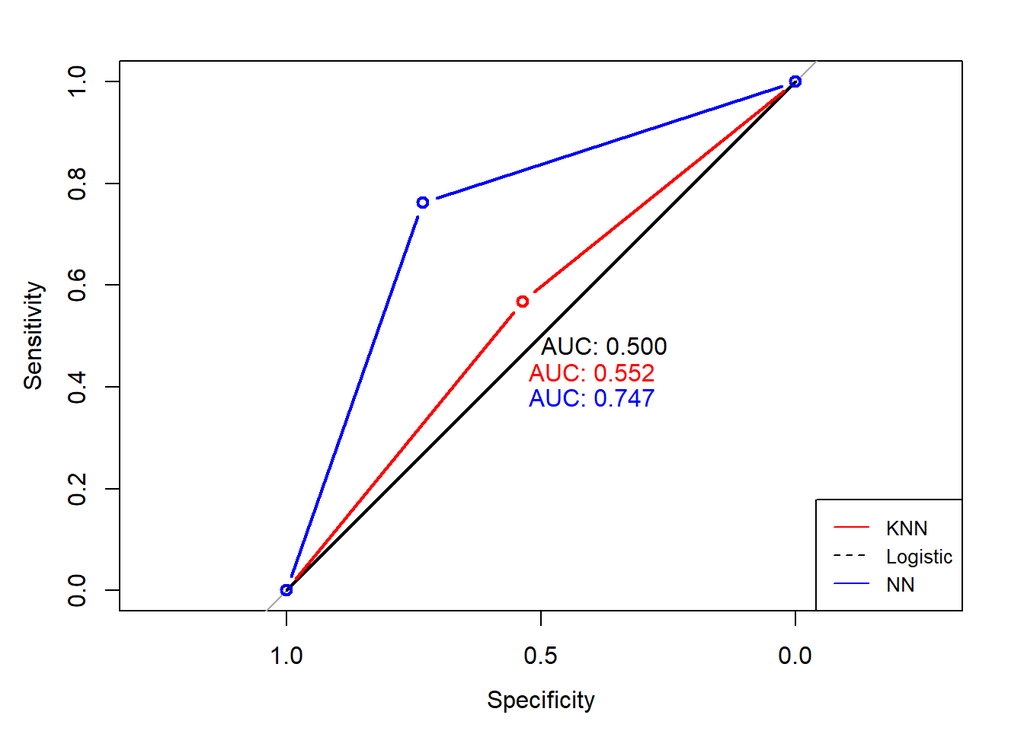

```r
roc_log <- roc(res_log, testData$response)
roc_knn <- roc(fit_knn, testData$response)
roc_nn <- roc(res_nn, testData$response)

auc_log <- auc(roc_log)
auc_knn <- auc(roc_knn)
auc_nn <- auc(roc_nn)

plot(roc_log, print.auc=TRUE)

lines(roc_knn, col="red", type='b')
text(0.4, 0.43, labels=sprintf("AUC: %0.3f", auc_knn), col="red")

lines(roc_nn, col="blue", type='b')
text(0.4, 0.38, labels=sprintf("AUC: %0.3f", auc_nn), col="blue")

legend("bottomright",legend = c("KNN","Logistic","NN"),col = c("red","black","blue"),lty=1:2, cex=0.8)
```

In the case of k-Nearest Neighbors (KNN), a score for a test instance is associated to the proportion of its neighbors belonging to the positive class, i.e. class distribution. So, the threshold for KNN is the number of neighbors needed to classify a test instance to a positive class.

#### From the above graph, we can see that NN has the highest accuracy.

Confusion matrix for final model NN.

```r
table(res_nn, testData$response)
```

```
##
## res_nn     0     1
##      0 30005 10984
##      1 11672 37339
```

##### Conclusion

Final model selected is NN.  
Generating output for test data.

```r
test <- read.table("D:/Github/ml-assignment/test-in.txt", header = FALSE, sep = " ", dec = ".")
res_nn_final <- predict(fit_nn,test)
res_nn_final <- ifelse(res_nn_final < 0.5,0,1)
test.in <- c("Manasi Anant Tondulkar",as.vector(res_nn_final))

t4 <- system.time({
    fwrite(list(test.in), file = "test-out.txt")
})
```